# Signal and Noise in ILEARN × WIDA ACCESS

Where English-language proficiency starts to predict content-test performance in Indiana

Damian W. Betebenner

National Center for the Improvement of Educational Assessment

Indiana · August 27, 2026

## AI Contribution & Authorship Statement

This presentation and the pipeline behind it represent the intellectual work of the author with substantive and continuous assistance from AI-based systems (xAI Grok, Anthropic Claude), used natively across the analysis, visualization, and exposition.

**The use of AI here is not incidental or peripheral — it is essential, embedded, and reflective of a methodological shift toward AI-native scholarship. This statement is offered in the spirit of methodological clarity and epistemic honesty.**

- **Analytic framing:** The signal-versus-noise reading of ILEARN × WIDA ACCESS, and the copula-asymmetry lens that expresses it, were developed in human–AI collaboration.
- **Mathematical formalization:** AI supported the dependence formalism — Kendall’s τ, the empirical copula and its radial-asymmetry surface $D(u,v) = C_n - \hat{C}_n$, the upper/lower tail-dependence coefficients $\lambda_U, \lambda_L$, Youden’s $J$, and the copula inversion behind the 50-50 next-year-proficiency cut.
- **Computational modules:** AI contributed to the R pipeline — rank and copula estimation, threshold scans, the inferred-exiter cohort, and the `ggplot2` figures — and to this reproducible reveal.js deck.
- **Authorship & responsibility:** The author retains full responsibility for all claims (ICMJE/AERA norms). AI is not listed as author, but its instrumental role is explicitly acknowledged. Findings describe testing patterns and empirical transitions — not an official IDOE roster or a legal exit rule.

## Roadmap

1. **The question** — is there a WIDA level where ILEARN stops looking like noise?
2. **Same-year signal** — location, not a jump in rank correlation; reading a cut with Youden’s J
3. **The shape of the dependence** — the copula is asymmetric, and the asymmetry is the signal
4. **After ACCESS stops** — inferred exiters versus stayers
5. **A 50-50 proficiency cut** — run as a contrast, not a recommendation
6. **What this says about 4.3 and 5.0**

**332,633** same-year ILEARN ELA × WIDA ACCESS Overall pairs after floor-score filters (**213,551** in 2021–2025). WIDA is labeled **Overall Composite** throughout — the LONG stores it as `READING`.

# The question

## What we asked

States require ELA of every student, including English learners. WIDA ACCESS is the English-language proficiency test used to decide whether a student can access content in English.

The working claim:

- At low WIDA (roughly Levels 1–2), ILEARN ELA behaves like **noise**: floor pile-up, near-independence of the two ranks.
- At higher WIDA a **signal** appears: ILEARN distributions that start to look like they can access English-language content.

If that transition is real, it is evidence about where an exit criterion should sit. It is **not** itself the legal exit rule.

Keep the construct straight

WIDA ACCESS measures English language proficiency. ILEARN ELA measures grade-level content. Native English speakers fail ILEARN. A content-test cut is not a language-access cut.

## Indiana’s exit anchors

Two numbers define the current policy — everything that follows asks whether the data agree with them.

Source: IDOE, *Exit Criteria for English Learners Guidance 2025–2026* (April 2025).

| Anchor | Meaning |
| --- | --- |
| **5.0** Overall composite | Absolute auto-exit |
| **4.3–4.9** Overall | Provisional pathway (grade 3+): ILP-committee additional evidence, not a pure scale-score cut |

WIDA LONG already stores L1–L4, **L4.3** (4.3–4.9 collapsed), L5, L6.

A fitted change-point describes where the content test starts to move with ACCESS. It may or may not equal the legal exit rule.

## Data and windows

Same-year, same-grade join: ILEARN `STUDENT_ID` = WIDA `ID`. Grades 3–8. Placeholder floors dropped (`ILEARN < 5000`, `WIDA == 100`).

| Window | Years | Role |
| --- | --- | --- |
| **Primary** | 2021–2025 | Stable ILEARN scale. The estimand. |
| Ranks only | 2026 | Both scales reset. Percentiles, not proficiency. |
| Contrast | 2017–2019 | ISTEP / first ILEARN year. Not pooled. |

2026 ILEARN `SCALE_SCORE` in the combined LONG is the equated **old** scale. Ranks agree; the proficiency classifier does not.

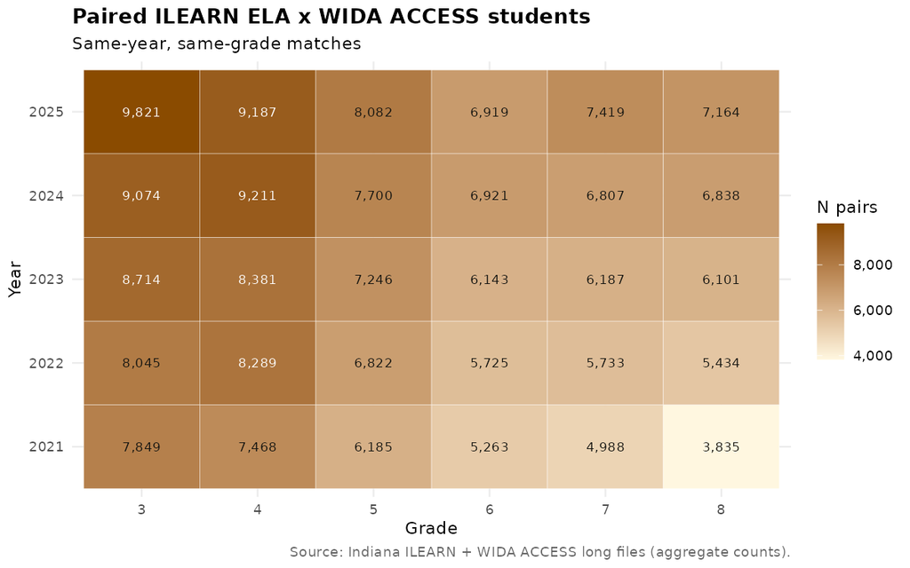

Paired N by year × grade. WIDA coverage in grades 3–8 is near-complete.

# Same-year signal

## The two tests are not independent

Before asking *where* a signal appears, the prior question is whether the two tests move together at all — which is what Kendall’s τ measures (0 = independence, 1 = identical rank order).

Primary-window Kendall’s τ is **0.51–0.61** (median **0.55**) — strong in every grade and year.

The signal-versus-noise claim is therefore **local**, not global. What changes with WIDA level is **where** EL students sit on ILEARN, not whether the two ranks suddenly start moving together.

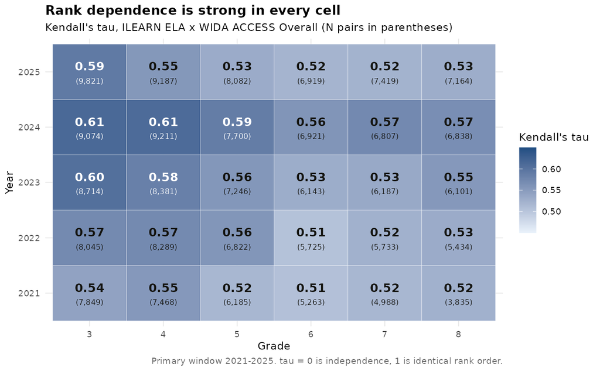

Kendall's τ by grade and year; N pairs in parentheses. Click to enlarge.

## The signal is location, not correlation

The core test of the hypothesis: as WIDA rises, does ILEARN rise by shifting the whole distribution upward, or merely by correlating more tightly *within* each band?

| WIDA level | N | Within-level τ | Median ILEARN percentile | P(ILEARN proficient) |
| --- | --- | --- | --- | --- |
| 1 | 6,048 | 0.03 | 17 | 0.00 |
| 2 | 7,057 | 0.10 | 24 | 0.00 |
| 4.3 (provisional) | 9,220 | 0.14 | 81 | 0.24 |
| 5 (auto-exit) | 3,610 | 0.18 | 93 | 0.60 |

**Location moves; correlation does not.** From L3 the ILEARN distribution walks up the grade — median percentile climbs from the high teens at L1 to the low 90s at L5 — while the **within-band τ stays modest** the whole way (restriction of range). The signal is *where* students sit, not a tightening rank correlation.

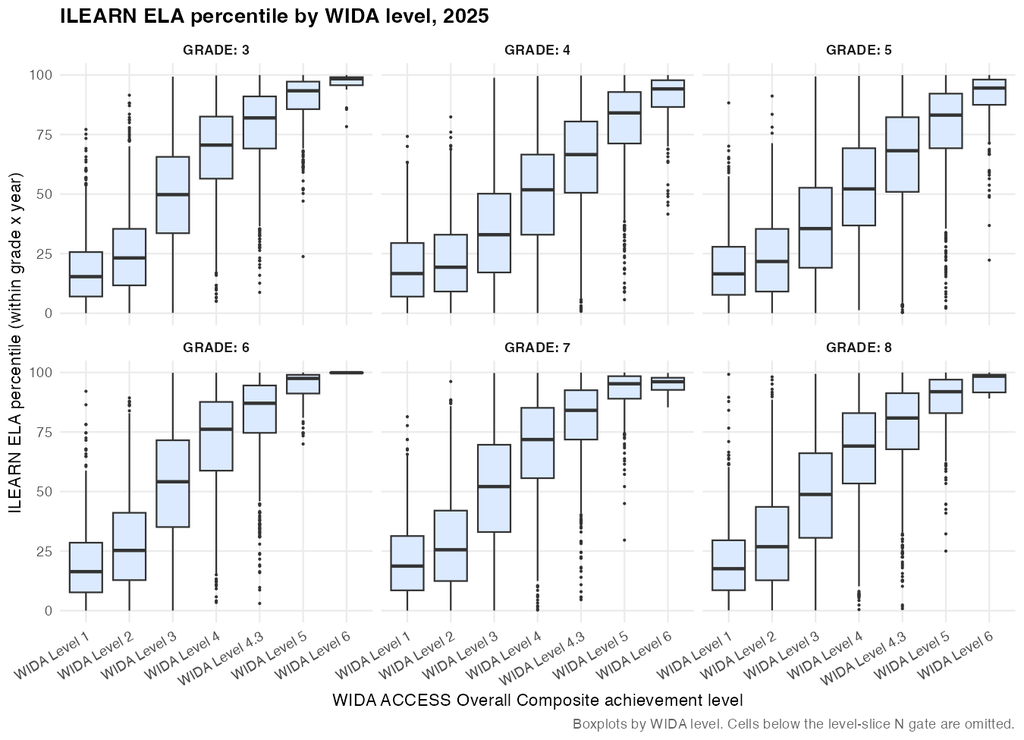

ILEARN ELA location by WIDA ACCESS Overall level, 2025.

## Reading a WIDA cut as a classifier

Any candidate cut turns WIDA ACCESS into a yes/no test: **WIDA ≥ cut** predicts “ILEARN-proficient.”

- **Sensitivity** — of the ILEARN-proficient students, the share the cut catches (true-positive rate).
- **Specificity** — of the not-proficient students, the share correctly left below (true-negative rate).

**Youden’s J = sensitivity + specificity − 1.** J runs from 0 (a coin flip) to 1 (perfect separation); on an ROC curve it is the vertical height above the chance diagonal. The **J-optimal cut** best separates the two groups.

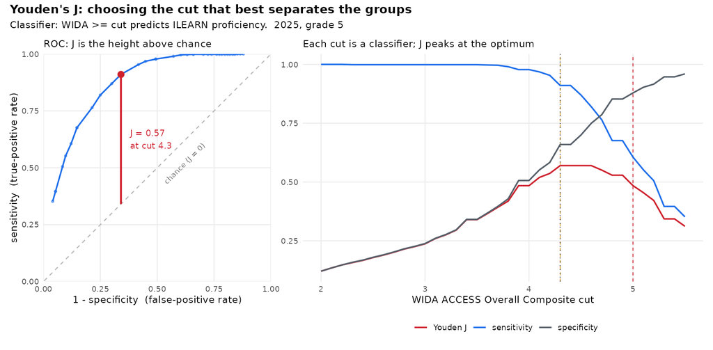

Youden's J: the cut that maximizes sensitivity + specificity − 1.

## Youden and the exit cut

The J-optimal WIDA cut is the score that best sorts EL students into ILEARN-proficient vs not. It is a **descriptive** answer — where the content signal separates best — not a legal rule.

Optimal ≠ correct construct

J optimizes agreement with **ILEARN proficiency** — a content outcome, not an English-access outcome. A statistically optimal classifier of the wrong target is still the wrong exit rule.

## The best statistical cut lands near 4.3, not 5.0

If we let the data choose the WIDA cut that best separates ILEARN-proficient students from the rest, where does it land relative to the 4.3 and 5.0 anchors?

Primary-window Youden-optimal WIDA cuts (same-year proficiency) have median **4.05**.

| Grade | Median optimal cut | SD |
| --- | --- | --- |
| 3 | 3.9 | 0.04 |
| 4 | 4.5 | 0.09 |
| 5 | 4.6 | 0.16 |
| 6 | 3.9 | 0.06 |
| 7 | 4.1 | 0.09 |
| 8 | 4.0 | 0.10 |

Grades 4–5 sit near the start of the **4.3** band; 3 and 6–8 sit a little below it. None of the Youden optima are at **5.0**. That is not an argument that 5.0 is the wrong legal exit — ILEARN proficiency is a high bar, and even students first reaching 5.0 are only about **0.40** ILEARN-proficient that year.

## Most of the climb happens before auto-exit

Following students the first year they reach a cut *while still tested*: how high are they already sitting on ILEARN by 4.3 versus 5.0?

Students first reaching a cut **while they still have a WIDA score**:

| Cut | N | ILEARN percentile before → at | P(proficient) before → at |
| --- | --- | --- | --- |
| 4.3 | 36,720 | 59 → 72 | 0.13 → 0.23 |
| 5.0 | 15,907 | 77 → 86 | 0.38 → 0.40 |

Most of the ILEARN location gain has already happened by the time a student hits auto-exit. This is still the **stayer** sample.

# The shape of the dependence

## Why symmetric copulas hide the story

The confirmatory families in step 03 — **t, Frank, Gaussian** — are all *exchangeable* and *radially symmetric*. Two consequences, both by construction:

- They force lower-tail dependence to equal upper-tail dependence: $\lambda_L = \lambda_U$.
- They treat the lower-left corner (both tests **low** — the WIDA floor) as a mirror of the upper-right corner (both **high**).

But the signal-vs-noise hypothesis is exactly the claim that those corners are **not** mirror images: low WIDA is noise, high WIDA is signal. A radially symmetric copula cannot represent that — so the departure from symmetry is not a nuisance to smooth away. It **is** the hypothesis, written in dependence-structure terms.

Measured directly, the copula is **exchangeable** (swapping the two tests barely moves it; index ≈ 0.008) but **radially asymmetric**.

## A picture of the asymmetry

If the dependence were radially symmetric this map would be flat grey — here is what it actually is.

The both-high **signal corner** and the both-low **noise corner** are **not mirror images** — the surface is far from flat, and the coupling is pulled toward high WIDA.

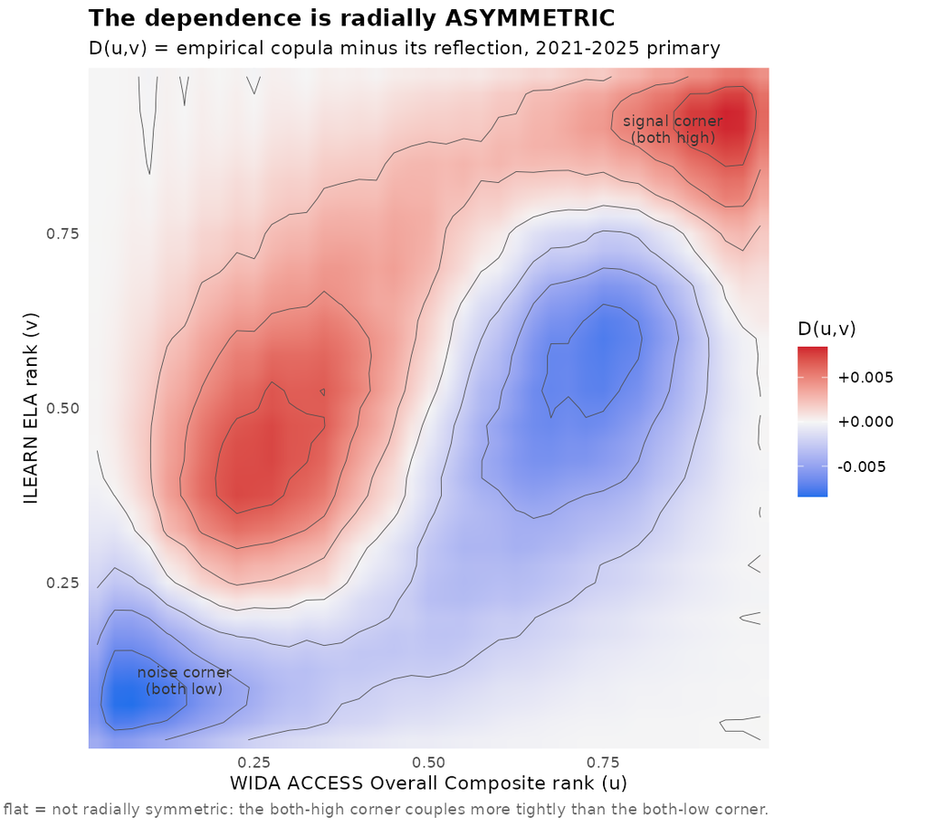

D(u,v) = empirical copula minus its reflection, primary window.

## The signal corner couples more than the noise corner

Another view of the same fact: how tightly the two tests co-move among the lowest scorers versus the highest.

Deep in the tail, upper-tail concordance $\lambda_U$ runs well above lower-tail $\lambda_L$: **both-high pairs co-occur more than both-low pairs.** The gap $\lambda_U-\lambda_L$ grows from **0.11 (2021)** to **0.22 (2025)** — stable in sign, strengthening in size, and invisible to any t / Frank / Gaussian fit.

A second, independent signature of the same access story.

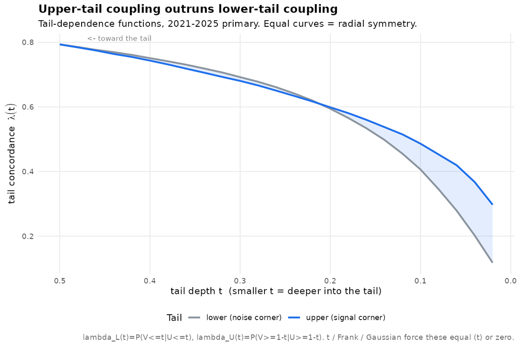

Upper- vs lower-tail dependence functions, primary window. The shaded gap is the asymmetry.

# After ACCESS stops

## Testing-pattern exit

With no official exit roster in these files, we infer exit from the one pattern both datasets share — who stops taking ACCESS.

Exit is the complementary event: ILEARN + WIDA at *t*, ILEARN only at *t+1*.

| Role | Pattern |
| --- | --- |
| **Exiter** | Both tests at *(t, g)*; ILEARN at *(t+1, g+1)*; no WIDA at *t+1* |
| **Stayer** | Both tests both years |
| **Never-EL** | ILEARN both years, no WIDA, not classified EL |
| **Attritor** | Both tests at *t*, no ILEARN at *t+1* (includes all grade 8) |

Not an official roster

These LONGs do not carry IDOE’s exit list. `<4.3` disappearances are documented, not treated as policy exits. Grade 8 cannot be followed.

**14,386** inferred exiters in the primary window (grades 3–7).

## Who actually leaves ACCESS

Turning to the event an exit rule actually governs: from which WIDA band do students leave ACCESS, and how has that shifted over five years?

- Almost every inferred exit comes from **≥5.0** — auto-exit is doing the work.
- The **4.3–4.9** committee band barely fills in until **2024**, then jumps.
- **<4.3** disappearances stay in the low hundreds every year — mobility or a missed test, not a policy pathway.

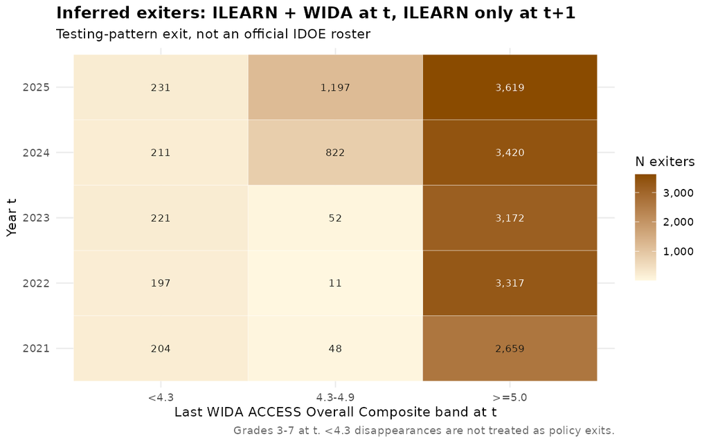

Inferred exiters by year × last WIDA ACCESS Overall band.

## The classification flag agrees only at 5.0

A testing-pattern “exit” only means something if it matches an official reclassification — does the EL-status flag agree these students left?

Share of inferred exiters whose ILEARN `EL_STATUS` moves LEP → Not an English Language Learner:

| Last WIDA | N | P(LEP → not EL) | P(still EL) |
| --- | --- | --- | --- |
| 4.3-4.9 | 985 | 0.20 – 0.37 | 0.53 – 0.76 |
| <4.3 | 833 | 0.20 – 0.37 | 0.53 – 0.76 |
| >=5.0 | 12,568 | 0.20 – 0.37 | 0.53 – 0.76 |

## No post-exit collapse

The central fear about exiting a student is academic collapse once services stop — do ACCESS leavers fall on ILEARN the next year?

No. **≥5.0** leavers sit ~9–10 percentile points **above** the never-EL median and hold or rise. **4.3–4.9** leavers sit near never-EL and dip about 2 points. **<4.3** disappearances stay on the ILEARN floor — like the students who never left.

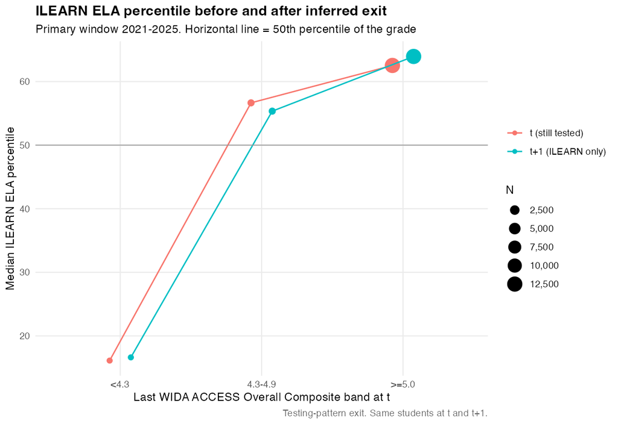

ILEARN ELA percentile at t (still tested) vs t+1 (ILEARN only).

| Band | N | Pctile t | Pctile t+1 | Δ | P(prof) t | P(prof) t+1 |
| --- | --- | --- | --- | --- | --- | --- |
| <4.3 | 833 | 16 | 17 | +1 | 0.04 | 0.05 |
| 4.3-4.9 | 985 | 57 | 55 | -2 | 0.04 | 0.05 |
| >=5.0 | 12,568 | 63 | 64 | +1 | 0.04 | 0.05 |

## Exit-year growth sits at or above 50

Beyond where exiters *stand*, how do they *grow* in their first year without ACCESS, relative to typical students?

ILEARN SGP at *t+1* is growth in the first year without ACCESS. **≥5.0** leavers post a median **58** — a right shift, not a left one. **4.3–4.9** leavers post ~**50**. Only **<4.3** disappearances are left-shifted (median **41**), which is what an unexpected drop among still-low students looks like.

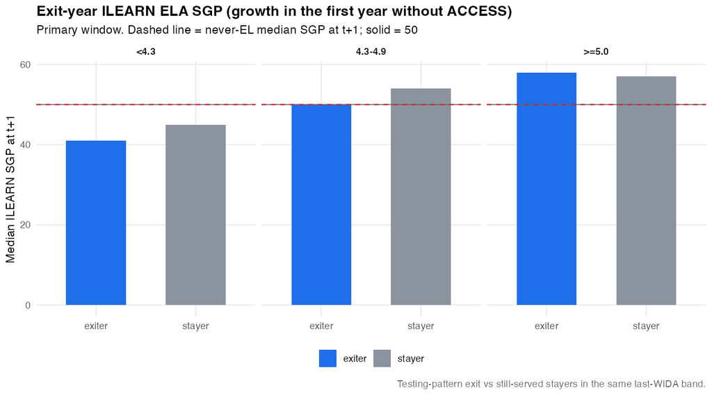

Median ILEARN SGP in the exit year. Faceted by last WIDA band.

| Band | N | Median SGP | P(SGP < 35) | P(SGP > 65) |
| --- | --- | --- | --- | --- |
| <4.3 | 833 | 41 | 0.44 | 0.26 |
| 4.3-4.9 | 985 | 50 | 0.44 | 0.26 |
| >=5.0 | 12,568 | 58 | 0.44 | 0.26 |

# A 50-50 proficiency cut

## The recipe that gets proposed

Find the WIDA ACCESS Overall score such that a student has better than a **50-50 chance** of being ILEARN ELA-proficient **the following year**.

Read the joint through a copula $C(U_t^{\mathrm{WIDA}}, V_{t+1}^{\mathrm{ILEARN}})$. Let $v^*$ be the ILEARN proficiency cut on the paired rank scale. Invert

$$P(V \ge v^* \mid U = u) = \tfrac{1}{2}$$

and map $u^*$ back to a WIDA proficiency level.

Also report the empirical local-window version: the first cut $c$ at which $P(\text{proficient}_{t+1} \mid \mathrm{WIDA}_t \approx c) \ge 0.5$.

**168,693** lagged pairs (WIDA at *t*, ILEARN at *t+1*) in the primary window.

## Why we do not recommend it

Wrong construct

ILEARN proficiency is not a proxy for being ready to leave EL services. Never-EL students — native and fluent English speakers who never took ACCESS — are **not** all ILEARN-proficient. In the primary window their P(proficient) is about **0.43**.

If the bar is “50-50 on next year’s ELA test,” a substantial share of never-EL students fail it. Using that bar to decide English-learner status asks ACCESS to predict a content outcome that English itself does not guarantee.

We still run the recipe. It is part of the conversation. It is filed as a **contrast**.

## What the copula actually returns

Running the 50-50 recipe honestly: the modeled probability of next-year ILEARN proficiency as a function of this year’s WIDA score.

The copula conditional (solid) and the local empirical rate (points) both rise with WIDA and cross the **0.50** line only near the top of the scale. The dotted line is the never-EL rate — the bar even fluent English speakers do not all clear.

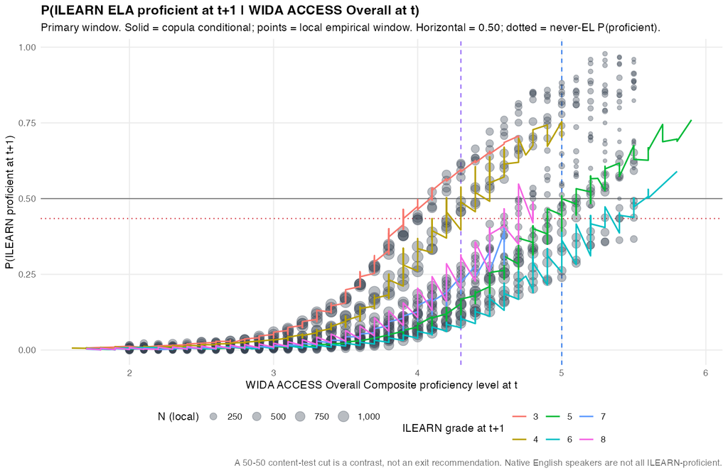

P(ILEARN proficient at t+1 | WIDA Overall at t). Solid = copula; points = local empirical; 0.50 line; dotted = never-EL.

## Where the 50-50 cut sits

Reading the cut off that curve and setting it against the policy anchors — and against the fact that not even all never-EL students clear this bar.

| Quantity | Value |
| --- | --- |
| Pooled copula cut (WIDA PL at t) | 4.70 |
| Pooled local-empirical cut | 5.10 |
| P(prof t+1 \| WIDA ≥ 4.3) | 0.42 |
| P(prof t+1 \| WIDA ≥ 5.0) | 0.59 |
| Local P(prof t+1 \| WIDA ≈ 4.3) | 0.27 |
| Local P(prof t+1 \| WIDA ≈ 5.0) | 0.48 |
| Never-EL P(ILEARN proficient) | 0.43 |

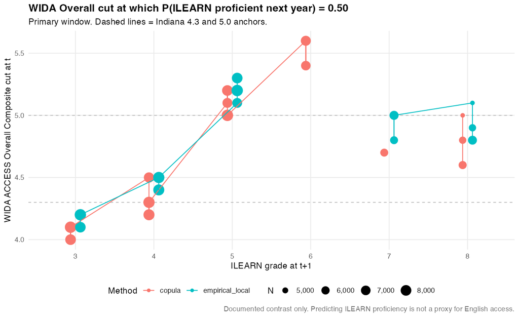

Fifty-fifty WIDA cut by ILEARN grade. Copula vs local empirical. Dashed = 4.3 and 5.0.

# 4.3 versus 5.0

## How the pieces fit

1. ILEARN ELA is not informative about English access below WIDA **Level 3**. L1–L2 is noise in the sense of the hypothesis.
2. Signal is clearly present by the **4.3–4.9** provisional band. That is also where Youden against ILEARN proficiency peaks.
3. **5.0 auto-exit** selects students already at the top of the ILEARN distribution. It is a conservative access standard, not the first point at which ILEARN stops looking like noise.
4. Students who leave ACCESS from **5.0** hold their ILEARN location and post slightly-above-typical growth. The classification flag agrees they exited.
5. Students who disappear from ACCESS at **4.3–4.9** also hold location — but most are still classified EL. The committee-band “exiter” cell is thin and contaminated.
6. The 50-50 next-year-proficiency recipe is in the JSON and the figures. It is **not** the recommended exit rule.

On these files the threshold debate is about **who is allowed to leave**, not about academic collapse after ACCESS stops.

## Reproducible artifacts

Every number in this deck is regenerable from two read-only source files, and no student-level record ever leaves the pipeline.

**One source, many channels.** The R pipeline (steps 00–09) is the single source of truth; the tables, JSON manifests, figures, and this deck are all *derived* from it and rebuilt by one command — so a corrected function or a new year of data propagates everywhere without hand-editing.

**Containment / FERPA.** Source LONGs are read-only and never copied in. Student-level pairs stay in gitignored `cache/`. Committed outputs are aggregates only: `write_output()` refuses `ID` / `STUDENT_ID` columns, and any cell below N = 10 is dropped.

| Layer | Where |
| --- | --- |
| Analysis | `00–09_*.R`, `R/`, `config.R` |
| Tables | `outputs/*.csv` |
| JSON manifests | `outputs/manifests/*.json` |
| Figures | `figures/*.png` (+ PDF) |
| This deck | `docs/index.html` |

```bash
Rscript run_all.R    # rebuild 00–09 + manifests
./docs/render.sh     # re-render this deck
```

# Where this could go next

## Open the black box: WIDA’s four domains

Everything here used the **Overall** composite — but WIDA scores four modalities, and English *content* access is largely a literacy story.

The same rank / copula / threshold machinery, run on **Listening, Speaking, Reading, and Writing** separately (pulling the domain subscores from the ACCESS source files), would ask *which* skill the ILEARN signal is actually attached to.

- Hypothesis: **Reading** and **Writing** carry most of the ILEARN-ELA dependence; **Listening** and **Speaking** far less.
- A **vine copula** on the four domains plus ILEARN would isolate the content signal *conditionally* — the dependence that survives after the other domains are held fixed.

**Would reveal:** whether a defensible exit rule should weight the literacy domains above the oral ones, rather than collapsing all four into a single Overall number.

## Is the low-WIDA “noise” real — or measurement error?

At Levels 1–2 the two ranks barely move together; the open question is whether that is genuine independence or just unreliability where both tests sit near their floors.

- **Disattenuate** the τ and the copula using each test’s conditional standard errors of measurement (CSEMs), where the source files carry them — noise from unreliability is not the same as noise from access.
- Model the ILEARN floor explicitly with a **censored / two-part (Tobit-style)** specification, separating “cannot yet access the test” from “low measured ability.”

**Would reveal:** how much of the L1–L2 “noise” is a substantive claim about English access versus an artifact of thin measurement information at the floor — which sets how much weight that region can bear.

## Direction and dynamics

The cross-sectional picture cannot say whether language *gain* precedes content *gain* — but the multi-year panel can.

- A **random-intercept cross-lagged panel model** (RI-CLPM) on WIDA$_t \rightarrow$ ILEARN$_{t+1}$ versus ILEARN$_t \rightarrow$ WIDA$_{t+1}$ tests the directional ordering of the access relationship.
- Add **time in program** (years since a student’s first ACCESS administration, recoverable from the panel) as a moderator: does the WIDA→ILEARN coupling strengthen with exposure?

**Would reveal:** whether rising English proficiency plausibly *drives* content access — the theory of action an exit rule assumes — or merely co-occurs with it.

## Beyond the median, beyond one cut

We summarized each WIDA level by its median and chose a single optimal cut; both hide heterogeneity that matters for who a rule serves.

- **Quantile / distributional regression** of ILEARN on WIDA PL models the *whole* conditional distribution — where the lower tail crosses proficiency, not just the center.
- **Finite-mixture / latent-class copulas** ask whether newcomers, long-term ELs, and students with interrupted schooling follow *different* WIDA→ILEARN maps that a single cut averages away.
- A **Bayesian or bootstrapped interval** on the τ(u) change-point would give the transition “region” an honest width.

**Would reveal:** which students a single Overall cut serves well, and which it systematically mis-sorts.

## From a threshold to a decision rule

A statistically optimal cut is not yet a policy; two extensions turn description into a defensible decision.

- **Cost-weighted Youden:** recompute the optimal cut as a function of the false-exit / false-hold cost ratio, making the value judgment explicit instead of fixing it implicitly at equal weights.
- **Multistate / survival modeling** of exit → reclassification → long-term-EL risk: what happens *years* after a student leaves, not only at $t{+}1$.
- **Subgroup invariance:** does the WIDA→ILEARN relationship hold across home language, grade of entry, and disability status, or does one cut carry hidden differential impact?

**Would reveal:** a cut chosen with stated priorities, audited for long-run consequences and equity — the form an actual recommendation would have to take.

## The through-line

Each next step sharpens the same question this deck opened with: where does a language test stop measuring language and start gating content?

The domain decomposition asks *which* language skill gates access; the measurement-error and distributional work ask *how sharply* and *for whom*; the panel and decision-analytic work ask *in what direction* and *at what cost*. None of them replaces the ILP committee — they give it a better-instrumented map of the band where the content test becomes a content test.